# **MNIST Digit Recognition Project**

#### 21 June 2019

# Digit Recognizer Project

A famous database that is used for pattern recognition is the MNIST handwritten digit database. It is a good database for people who want to try learning techniques and pattern recognition methods on real-world data while spending minimal efforts on preprocessing and formatting.

It is also the next classification problem that we will explore together. (I promise, my next project will not be a classification problem)

## Project Description

*MNIST ("Modified National Institute of Standards and Technology") is the de facto “hello world” dataset of computer vision. Since its release in 1999, this classic dataset of handwritten images has served as the basis for benchmarking classification algorithms. As new machine learning techniques emerge, MNIST remains a reliable resource for researchers and learners alike.*

*In this competition, your goal is to correctly identify digits from a dataset of tens of thousands of handwritten images. We’ve curated a set of tutorial-style kernels which cover everything from regression to neural networks. We encourage you to experiment with different algorithms to learn first-hand what works well and how techniques compare.*

For a detailed project insight, check out the link: https://www.kaggle.com/c/digit-recognizer

## Objective

Using the given dataset, we will try to categorize a 28x28 image of a digit with its corresponding label. We will then use a test set to determine how accurately our model can predict a digit image.

Once the model is ready, I will build an interactive website where a user can draw a digit and see whether my pre-loaded model can predict it accurately or not.

## Data Analysis

- The total dataset contains the pixel values for 70,000 images. This dataset has been split into a training set and a test set in the ratio of 6:4. Therefore, the *training set* contains *42,000* image pixel values and *test set* contains *28,000* image pixel values.
- The dataset has stored each pixel in a separate column, thus having 784 columns as each image is 28pixel wide and 28pixel high.
- The images have also been centered as is mentioned in the MNIST database website (http://yann.lecun.com/exdb/mnist/).

### Independant Variables

- *pixel**X** -* Each of the 784 pixels (X ranges from 0 to 783)

### Dependant Variable

- *label* - The description of the image

```python
# Importing Libraries
import pandas as pd
import matplotlib.pyplot as plt
import numpy as np

# Import Data
training_set = pd.read_csv('data/train.csv')
training_set.head()
```

|  | label | pixel0 | pixel1 | pixel2 | pixel3 | pixel4 | pixel5 | pixel6 | pixel7 | pixel8 | ... | pixel774 | pixel775 | pixel776 | pixel777 | pixel778 | pixel779 | pixel780 | pixel781 | pixel782 | pixel783 |
| --- | --- | --- | --- | --- | --- | --- | --- | --- | --- | --- | --- | --- | --- | --- | --- | --- | --- | --- | --- | --- | --- |
| 0 | 1 | 0 | 0 | 0 | 0 | 0 | 0 | 0 | 0 | 0 | ... | 0 | 0 | 0 | 0 | 0 | 0 | 0 | 0 | 0 | 0 |
| 1 | 0 | 0 | 0 | 0 | 0 | 0 | 0 | 0 | 0 | 0 | ... | 0 | 0 | 0 | 0 | 0 | 0 | 0 | 0 | 0 | 0 |
| 2 | 1 | 0 | 0 | 0 | 0 | 0 | 0 | 0 | 0 | 0 | ... | 0 | 0 | 0 | 0 | 0 | 0 | 0 | 0 | 0 | 0 |
| 3 | 4 | 0 | 0 | 0 | 0 | 0 | 0 | 0 | 0 | 0 | ... | 0 | 0 | 0 | 0 | 0 | 0 | 0 | 0 | 0 | 0 |
| 4 | 0 | 0 | 0 | 0 | 0 | 0 | 0 | 0 | 0 | 0 | ... | 0 | 0 | 0 | 0 | 0 | 0 | 0 | 0 | 0 | 0 |

5 rows × 785 columns

## Insights from Data

We can see that the images cover all 10 digits which are 0 to 9. This can be seen in the second column, which has all 10 digits mentioned (ignore the first column as it shows the first occurence of the corresponding digit label).

We can also see that the training set has around 4000-4500 images per digit, which can be used to train the classification model.

```
1     0
0     1
16    2
7     3
3     4
8     5
21    6
6     7
10    8
11    9
Name: label, dtype: int64
```

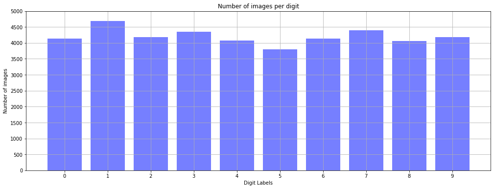

```python
print(training_set.label.drop_duplicates().sort_values())
stored_index = training_set.label.drop_duplicates().sort_values().index

plt.figure(figsize=(17,6))
plt.bar(training_set.label.value_counts().index, training_set.label.value_counts(), color=(118/255,127/255,255/255))
plt.grid(True)
plt.xticks(np.arange(10))
plt.yticks(np.arange(0,5001,500))
plt.xlabel('Digit Labels')
plt.ylabel('Number of images')
plt.title('Number of images per digit')
plt.show()
```

### Pixel Value Range

We can also see that the values in each row range from 0 to 255. This value represents the color of the corresponding pixel. **0 is Black** and **255 is White**.

Below are few random images which have their pixel range displayed.

```python
image_id = 0
print("Pixel value range of image index %d: %d - %d\n" %(image_id,training_set.iloc[image_id].min(),training_set.iloc[image_id].max()))
image_id = 1325
print("Pixel value range of image index %d: %d - %d\n" %(image_id,training_set.iloc[image_id].min(),training_set.iloc[image_id].max()))
image_id = 29483
print("Pixel value range of image index %d: %d - %d" %(image_id,training_set.iloc[image_id].min(),training_set.iloc[image_id].max()))
```

```
Pixel value range of image index 0: 0 - 255

Pixel value range of image index 1325: 0 - 255

Pixel value range of image index 29483: 0 - 255
```

### Visualizing the Data

Since there are only 784 pixels for each 28x28 image, we can safely assume that each image has only *one color channel* and is a *Grayscale* image. If they had *3 channels or 4 channels*, they would be *RGB or RGBA* images.

We can see that by displaying few of the images from the training set.

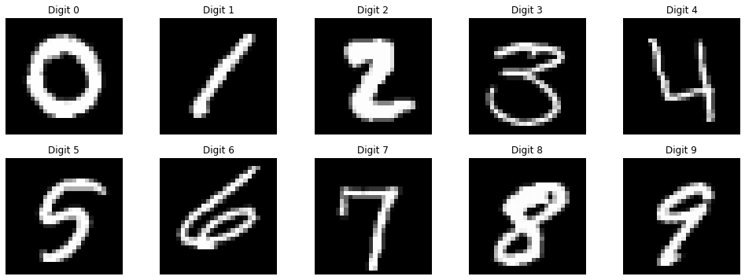

```python
plt.figure(figsize=(17,6))
for i in range(stored_index.size):
    plt.subplot(2,5,i+1)
    plt.title("Digit %d" %(i))
    plt.axis(False)
    plt.imshow(training_set.iloc[stored_index[i],1:].values.reshape((28,28)), cmap='gray')
```

## Training the Model

We shall use the winner of the last project, i.e., the **Kernel SVM** along with the **Random Forest classifier**.

We will also use a **Convolutional Neural Network (CNN)** to see if we can do better than the aforementioned models.

### Kernel SVM vs Random Forests

Looks like the **Random Forest Classifier** performed better than the Kernel SVM model with an accuracy of **96.4%**. Not bad at all. But let us see if we can create a CNN that provides a higher accuracy.

[figure not shown]

### CNN Model Development

#### NOTE:

All the classifiers have been fit using Spyder IDE offline as the Jupyter Notebook was unable to fit the dataset.  
Hence, I will be manually adding the print to display the training accuracy and validation accuracy.  
COMMON parameters used in the fit() method:

- *batch_size: 50*
- *validation_split: 0.2*

Let us start with a basic CNN model to compare the accuracy with the previous two models.

```python
# Extracting data from dataframe
X = training_set.iloc[:,1:].values
Y = training_set.iloc[:,0].values
px_len = 28

# Normalizing the Pixels
X = X/255

# Encoding for the Label Column
Y = pd.Categorical(Y)
Y = pd.get_dummies(Y)

# Reshaping X to a 2D matrix (28x28pixel) with 1channel
X = X.reshape((len(X),px_len, px_len, 1))
```

```python
# Importing Libraries for the CNN
from statistics import mean
from keras.models import Sequential
from keras.layers import Dense
from keras.layers import Conv2D
from keras.layers import MaxPooling2D
from keras.layers import Flatten
```

```python
classifier = Sequential()

classifier.add(Conv2D(32, (5,5), input_shape=(28,28,1), activation='relu'))
classifier.add(MaxPooling2D(pool_size=(2,2)))

classifier.add(Conv2D(64, (5,5), activation='relu'))
classifier.add(MaxPooling2D(pool_size=(2,2)))

classifier.add(Flatten())

classifier.add(Dense(units=256, activation='relu'))
classifier.add(Dense(units=10, activation='sigmoid'))

#classifier.compile(optimizer = 'adam', loss = 'categorical_crossentropy', metrics = ['accuracy'])
#
#mem = classifier.fit(x=X,
#                   y=Y,
#                   batch_size=50,
#                   epochs=20,
#                   validation_split=0.2)
#
#print("Max Train Acc: {1:.3f}%, Mean Train Acc: {2:.3f}%, Max Test Acc: {3:.3f}%, Mean Test Acc: {4:.3f}%".format(
#          max(mem.history['acc'])*100,
#          mean(mem.history['acc'])*100,
#          max(mem.history['val_acc'])*100,
#          mean(mem.history['val_acc'])*100))
#
#plt.figure(figsize=(17,5))
#plt.plot(mem.history['val_acc'])
#plt.title('Model Validation Accuracy')
#plt.xlabel('Epoch')
#plt.ylabel('Accuracy')
#plt.grid(True)
#plt.show()

print("Max Train Acc: 99.896%, Mean Train Acc: 99.279%, Max Test Acc: 99.155%, Mean Test Acc: 98.817%")
```

```
Max Train Acc: 99.896%, Mean Train Acc: 99.279%, Max Test Acc: 99.155%, Mean Test Acc: 98.817%
```

[figure not shown]

From the output, we can see that the CNN in its simplest form is already performing better than the Random Forest classifier. The accuracy of the CNN is already **around 2.5% higher**.

Now let us perform a series of experiments on the CNN to make it perform even better.

### Experiment 1: Number of Dense Units

The first experiment tests the optimal number of Dense units for the CNN. The options considered are:

- units = 64
- units = 128
- units = 256
- units = 512
- units = 1024

```python
nets = 5 # To run the 5 scenarios
classifier  = [0]*nets
mem = [0]*nets
for i in range(nets):
    classifier[i] = Sequential()

    classifier[i].add(Conv2D(32, (5,5), input_shape = (28, 28, 1), activation = 'relu'))
    classifier[i].add(MaxPooling2D(pool_size = (2, 2)))

    classifier[i].add(Conv2D(64, (5,5), activation = 'relu'))
    classifier[i].add(MaxPooling2D(pool_size = (2, 2)))

    classifier[i].add(Flatten())

    classifier[i].add(Dense(units = 2**(6+i), activation = 'relu')) # Generates 64,128,256,512 and 1024 on each run
    classifier[i].add(Dense(units = 10, activation = 'sigmoid'))

    classifier[i].compile(optimizer = 'adam', loss = 'categorical_crossentropy', metrics = ['accuracy'])

#    mem[i] = classifier[i].fit(x=X,
#                   y=Y,
#                   batch_size=50,
#                   epochs=20,
#                   validation_split=0.2)
#
print("Epoch = 20")
#names = ["64 units","128 units","256 units","512 units","1024 units"]
#
#plt.figure(figsize=(17,5))
#for j in range(nets):
#    print("CNN: {0}, Max Train Acc: {1:.3f}%, Mean Train Acc: {2:.3f}%, Max Test Acc: {3:.3f}%, Mean Test Acc: {4:.3f}%".format(
#          names[j],
#          max(mem[j].history['acc'])*100,
#          mean(mem[j].history['acc'])*100,
#          max(mem[j].history['val_acc'])*100,
#          mean(mem[j].history['val_acc'])*100))
#
#
#    plt.plot(mem[j].history['val_acc'])
#plt.title('Model Validation Accuracy')
#plt.xlabel('Epoch')
#plt.ylabel('Accuracy')
#plt.legend(names)
#plt.grid(True)
#plt.show()

print("CNN: 64 units, Max Train Acc: 99.866%, Mean Train Acc: 99.085%, Max Test Acc: 99.095%, Mean Test Acc: 98.729%")
print("CNN: 128 units, Max Train Acc: 99.905%, Mean Train Acc: 99.224%, Max Test Acc: 99.286%, Mean Test Acc: 98.819%")
print("CNN: 256 units, Max Train Acc: 99.893%, Mean Train Acc: 99.255%, Max Test Acc: 99.167%, Mean Test Acc: 98.802%")
print("CNN: 512 units, Max Train Acc: 99.851%, Mean Train Acc: 99.300%, Max Test Acc: 99.167%, Mean Test Acc: 98.802%")
print("CNN: 1024 units, Max Train Acc: 99.884%, Mean Train Acc: 99.320%, Max Test Acc: 99.202%, Mean Test Acc: 98.860%")
```

```
Epoch = 20
CNN: 64 units, Max Train Acc: 99.866%, Mean Train Acc: 99.085%, Max Test Acc: 99.095%, Mean Test Acc: 98.729%
CNN: 128 units, Max Train Acc: 99.905%, Mean Train Acc: 99.224%, Max Test Acc: 99.286%, Mean Test Acc: 98.819%
CNN: 256 units, Max Train Acc: 99.893%, Mean Train Acc: 99.255%, Max Test Acc: 99.167%, Mean Test Acc: 98.802%
CNN: 512 units, Max Train Acc: 99.851%, Mean Train Acc: 99.300%, Max Test Acc: 99.167%, Mean Test Acc: 98.802%
CNN: 1024 units, Max Train Acc: 99.884%, Mean Train Acc: 99.320%, Max Test Acc: 99.202%, Mean Test Acc: 98.860%
```

[figure not shown]

### Experiment 2: Dropout

The second experiment is to check how much dropout we should add to each layer. Keep in mind that dropout is used to avoid overfitting. The options considered are *0%, 10%, 20%, 30%, 40% and 50%*.

```python
from keras.layers import Dropout

nets = 6 # To run the 6 scenarios
classifier  = [0]*nets
mem = [0]*nets
for i in range(nets):
    classifier[i] = Sequential()

    classifier[i].add(Conv2D(32, (5,5), input_shape = (28, 28, 1), activation = 'relu'))
    classifier[i].add(MaxPooling2D(pool_size = (2, 2)))
    classifier[i].add(Dropout(rate=0.1*i)) # Generates the appropriate percentage on each run

    classifier[i].add(Conv2D(64, (5,5), activation = 'relu'))
    classifier[i].add(MaxPooling2D(pool_size = (2, 2)))
    classifier[i].add(Dropout(rate=0.1*i))

    classifier[i].add(Flatten())

    classifier[i].add(Dense(units = 128, activation = 'relu'))
    classifier[i].add(Dropout(rate=0.1*i))

    classifier[i].add(Dense(units = 10, activation = 'sigmoid'))

    classifier[i].compile(optimizer = 'adam', loss = 'categorical_crossentropy', metrics = ['accuracy'])

#    mem[i] = classifier[i].fit(x=X,
#                   y=Y,
#                   batch_size=50,
#                   epochs=20,
#                   validation_split=0.2)
#
print("Epoch = 20")
#names = ["D - 0%","D - 10%","D - 20%","D - 30%","D - 40%","D - 50%"]
#
#plt.figure(figsize=(17,5))
#for j in range(nets):
#    print("CNN: {0}, Max Train Acc: {1:.3f}%, Mean Train Acc: {2:.3f}%, Max Test Acc: {3:.3f}%, Mean Test Acc: {4:.3f}%".format(
#          names[j],
#          max(mem[j].history['acc'])*100,
#          mean(mem[j].history['acc'])*100,
#          max(mem[j].history['val_acc'])*100,
#          mean(mem[j].history['val_acc'])*100))
#
#
#    plt.plot(mem[j].history['val_acc'])
#plt.title('Model Validation Accuracy')
#plt.xlabel('Epoch')
#plt.ylabel('Accuracy')
#plt.legend(names)
#plt.grid(True)
#plt.show()

print("CNN: D - 0%, Max Train Acc: 99.884%, Mean Train Acc: 99.193%, Max Test Acc: 99.179%, Mean Test Acc: 98.792%")
print("CNN: D - 10%, Max Train Acc: 99.798%, Mean Train Acc: 99.002%, Max Test Acc: 99.321%, Mean Test Acc: 99.039%")
print("CNN: D - 20%, Max Train Acc: 99.601%, Mean Train Acc: 98.692%, Max Test Acc: 99.321%, Mean Test Acc: 99.030%")
print("CNN: D - 30%, Max Train Acc: 99.423%, Mean Train Acc: 98.332%, Max Test Acc: 99.298%, Mean Test Acc: 98.954%")
print("CNN: D - 40%, Max Train Acc: 99.021%, Mean Train Acc: 97.874%, Max Test Acc: 99.321%, Mean Test Acc: 99.023%")
print("CNN: D - 50%, Max Train Acc: 98.515%, Mean Train Acc: 97.022%, Max Test Acc: 99.321%, Mean Test Acc: 98.874%")
```

```
Epoch = 20
CNN: D - 0%, Max Train Acc: 99.884%, Mean Train Acc: 99.193%, Max Test Acc: 99.179%, Mean Test Acc: 98.792%
CNN: D - 10%, Max Train Acc: 99.798%, Mean Train Acc: 99.002%, Max Test Acc: 99.321%, Mean Test Acc: 99.039%
CNN: D - 20%, Max Train Acc: 99.601%, Mean Train Acc: 98.692%, Max Test Acc: 99.321%, Mean Test Acc: 99.030%
CNN: D - 30%, Max Train Acc: 99.423%, Mean Train Acc: 98.332%, Max Test Acc: 99.298%, Mean Test Acc: 98.954%
CNN: D - 40%, Max Train Acc: 99.021%, Mean Train Acc: 97.874%, Max Test Acc: 99.321%, Mean Test Acc: 99.023%
CNN: D - 50%, Max Train Acc: 98.515%, Mean Train Acc: 97.022%, Max Test Acc: 99.321%, Mean Test Acc: 98.874%
```

[figure not shown]

From the experiment, a dropout rate of *10% - 20%* seems to create the best results. Another test can be run with a dropout percent difference of 5% instead of 10% to determine the absolute best among the two.

```python
print("CNN: D - 0%, Max Train Acc: 99.878%, Mean Train Acc: 99.113%, Max Test Acc: 99.143%, Mean Test Acc: 98.644%")
print("CNN: D - 5%, Max Train Acc: 99.821%, Mean Train Acc: 99.130%, Max Test Acc: 99.214%, Mean Test Acc: 98.927%")
print("CNN: D - 10%, Max Train Acc: 99.744%, Mean Train Acc: 98.979%, Max Test Acc: 99.286%, Mean Test Acc: 98.937%")
print("CNN: D - 15%, Max Train Acc: 99.738%, Mean Train Acc: 98.851%, Max Test Acc: 99.286%, Mean Test Acc: 98.973%")
print("CNN: D - 20%, Max Train Acc: 99.563%, Mean Train Acc: 98.689%, Max Test Acc: 99.310%, Mean Test Acc: 98.967%")
print("CNN: D - 25%, Max Train Acc: 99.497%, Mean Train Acc: 98.499%, Max Test Acc: 99.310%, Mean Test Acc: 99.018%")
```

```
CNN: D - 0%, Max Train Acc: 99.878%, Mean Train Acc: 99.113%, Max Test Acc: 99.143%, Mean Test Acc: 98.644%
CNN: D - 5%, Max Train Acc: 99.821%, Mean Train Acc: 99.130%, Max Test Acc: 99.214%, Mean Test Acc: 98.927%
CNN: D - 10%, Max Train Acc: 99.744%, Mean Train Acc: 98.979%, Max Test Acc: 99.286%, Mean Test Acc: 98.937%
CNN: D - 15%, Max Train Acc: 99.738%, Mean Train Acc: 98.851%, Max Test Acc: 99.286%, Mean Test Acc: 98.973%
CNN: D - 20%, Max Train Acc: 99.563%, Mean Train Acc: 98.689%, Max Test Acc: 99.310%, Mean Test Acc: 98.967%
CNN: D - 25%, Max Train Acc: 99.497%, Mean Train Acc: 98.499%, Max Test Acc: 99.310%, Mean Test Acc: 99.018%
```

[figure not shown]

### Experiment 3: Converting the bigger convolutional layer to two smaller ones

For the second last experiment, instead of using the *Conv2D()* layer with a kernel size of *(5,5)*, let us replace it with 2 *Conv2D()* layers with kernel sizes *(3,3)* each.

```python
nets = 2 # To run the 2 scenarios
classifier  = [0]*nets
mem = [0]*nets
for i in range(nets):
    classifier[i] = Sequential()

    if i==0:
        classifier[i].add(Conv2D(32, (5,5), input_shape = (28, 28, 1), activation = 'relu'))
    else:
        classifier[i].add(Conv2D(32, (3,3), input_shape = (28, 28, 1), activation = 'relu'))
        classifier[i].add(Conv2D(32, (3,3), activation = 'relu'))
    classifier[i].add(MaxPooling2D(pool_size = (2, 2)))
    classifier[i].add(Dropout(rate=0.15))

    if i==0:
        classifier[i].add(Conv2D(64, (5,5), activation = 'relu'))
    else:
        classifier[i].add(Conv2D(64, (3,3), activation = 'relu'))
        classifier[i].add(Conv2D(64, (3,3), activation = 'relu'))
    classifier[i].add(MaxPooling2D(pool_size = (2, 2)))
    classifier[i].add(Dropout(rate=0.15))

    classifier[i].add(Flatten())

    classifier[i].add(Dense(units = 128, activation = 'relu'))
    classifier[i].add(Dropout(rate=0.15))

    classifier[i].add(Dense(units = 10, activation = 'sigmoid'))

    classifier[i].compile(optimizer = 'adam', loss = 'categorical_crossentropy', metrics = ['accuracy'])

#    mem[i] = classifier[i].fit(x=X,
#                   y=Y,
#                   batch_size=50,
#                   epochs=25,
#                   validation_split=0.2)
#
print("Epoch = 25")
#names = ["C5","C3C3"]
#
#plt.figure(figsize=(17,5))
#for j in range(nets):
#    print("CNN: {0}, Max Train Acc: {1:.3f}%, Mean Train Acc: {2:.3f}%, Max Test Acc: {3:.3f}%, Mean Test Acc: {4:.3f}%".format(
#          names[j],
#          max(mem[j].history['acc'])*100,
#          mean(mem[j].history['acc'])*100,
#          max(mem[j].history['val_acc'])*100,
#          mean(mem[j].history['val_acc'])*100))
#
#
#    plt.plot(mem[j].history['val_acc'])
#plt.title('Model Validation Accuracy')
#plt.xlabel('Epoch')
#plt.ylabel('Accuracy')
#plt.legend(names)
#plt.grid(True)
#plt.show()

print("CNN: C5, Max Train Acc: 99.738%, Mean Train Acc: 99.006%, Max Test Acc: 99.310%, Mean Test Acc: 99.012%")
print("CNN: C3C3, Max Train Acc: 99.795%, Mean Train Acc: 99.060%, Max Test Acc: 99.310%, Mean Test Acc: 99.067%")
```

```
Epoch = 25
CNN: C5, Max Train Acc: 99.738%, Mean Train Acc: 99.006%, Max Test Acc: 99.310%, Mean Test Acc: 99.012%
CNN: C3C3, Max Train Acc: 99.795%, Mean Train Acc: 99.060%, Max Test Acc: 99.310%, Mean Test Acc: 99.067%
```

[figure not shown]

#### Result

The splitting of the convolutional layer has provided **better** results. Thus, the future experiments will continue with 2 smaller convolutional layer instead of one.

### Experiment 4: Using Batch Normalization

```python
from keras.layers import BatchNormalization

nets = 2 # To run the 2 scenarios
classifier  = [0]*nets
mem = [0]*nets
for i in range(nets):
    classifier[i] = Sequential()

    classifier[i].add(Conv2D(32, (3,3), input_shape = (28, 28, 1), activation = 'relu'))
    if i>0:
        classifier[i].add(BatchNormalization())
    classifier[i].add(Conv2D(32, (3,3), activation = 'relu'))
    if i>0:
        classifier[i].add(BatchNormalization())
    classifier[i].add(MaxPooling2D(pool_size = (2, 2)))
    if i>0:
        classifier[i].add(BatchNormalization())
    classifier[i].add(Dropout(rate=0.15))

    classifier[i].add(Conv2D(64, (3,3), activation = 'relu'))
    if i>0:
        classifier[i].add(BatchNormalization())
    classifier[i].add(Conv2D(64, (3,3), activation = 'relu'))
    if i>0:
        classifier[i].add(BatchNormalization())
    classifier[i].add(MaxPooling2D(pool_size = (2, 2)))
    classifier[i].add(Dropout(rate=0.15))

    classifier[i].add(Flatten())

    classifier[i].add(Dense(units = 128, activation = 'relu'))
    if i>0:
        classifier[i].add(BatchNormalization())
    classifier[i].add(Dropout(rate=0.15))

    classifier[i].add(Dense(units = 10, activation = 'sigmoid'))

    classifier[i].compile(optimizer = 'adam', loss = 'categorical_crossentropy', metrics = ['accuracy'])

#    mem[i] = classifier[i].fit(x=X,
#                   y=Y,
#                   batch_size=50,
#                   epochs=30,
#                   validation_split=0.2)
#
print("Epoch = 30")
#names = ["without BN","with BN"]
#
#plt.figure(figsize=(17,5))
#for j in range(nets):
#    print("CNN: {0}, Max Train Acc: {1:.3f}%, Mean Train Acc: {2:.3f}%, Max Test Acc: {3:.3f}%, Mean Test Acc: {4:.3f}%".format(
#          names[j],
#          max(mem[j].history['acc'])*100,
#          mean(mem[j].history['acc'])*100,
#          max(mem[j].history['val_acc'])*100,
#          mean(mem[j].history['val_acc'])*100))
#
#
#    plt.plot(mem[j].history['val_acc'])
#plt.title('Model Validation Accuracy')
#plt.xlabel('Epoch')
#plt.ylabel('Accuracy')
#plt.legend(names)
#plt.grid(True)
#plt.show()

print("CNN: without BN, Max Train Acc: 99.801%, Mean Train Acc: 99.202%, Max Test Acc: 99.345%, Mean Test Acc: 99.079%")
print("CNN: with BN, Max Train Acc: 99.821%, Mean Train Acc: 99.177%, Max Test Acc: 99.464%, Mean Test Acc: 99.225%")
```

```
Epoch = 30
CNN: without BN, Max Train Acc: 99.801%, Mean Train Acc: 99.202%, Max Test Acc: 99.345%, Mean Test Acc: 99.079%
CNN: with BN, Max Train Acc: 99.821%, Mean Train Acc: 99.177%, Max Test Acc: 99.464%, Mean Test Acc: 99.225%
```

[figure not shown]

#### Result

We can clearly see that Batch Normalization does increase the accuracy by a valuable margin. Therefore, it is added to the final model.

## Final Results

Before tweaking the CNN, we had already determined that it was the best model to classify the MNIST dataset. The final print and figure show the difference between the *first CNN model* and the *final CNN model*.

### First Model

- Maximum Validation Accuracy: *99.214%*
- Mean Validation Accuracy: *98.819%*

### Last Model

- Max Validation Accuracy: *99.476%*
- Mean Validation Accuracy: *99.196%*

We can see that the accuracy has improved by *0.377%* ,i.e., it is **99.196%**.

### Kaggle Submission Results

With the **Kaggle Test set**, this final CNN model achieved an accuracy of **99.242%**.

```python
nets = 2
classifier  = [0]*nets
mem = [0]*nets
for i in range(nets):
    # Initializing the CNN
    classifier[i] = Sequential()

    if i>0:
        classifier[i].add(Conv2D(32, (3,3), input_shape = (28, 28, 1), activation = 'relu'))
        classifier[i].add(BatchNormalization())
        classifier[i].add(Conv2D(32, (3,3), activation = 'relu'))
        classifier[i].add(BatchNormalization())
        classifier[i].add(MaxPooling2D(pool_size = (2, 2)))
        classifier[i].add(BatchNormalization())
        classifier[i].add(Dropout(rate=0.15))

        # Adding a second convolutional layer
        classifier[i].add(Conv2D(64, (3,3), activation = 'relu'))
        classifier[i].add(BatchNormalization())
        classifier[i].add(Conv2D(64, (3,3), activation = 'relu'))
        classifier[i].add(BatchNormalization())
        classifier[i].add(MaxPooling2D(pool_size = (2, 2)))
        classifier[i].add(BatchNormalization())
        classifier[i].add(Dropout(rate=0.15))

        # Step 3 - Flattening
        classifier[i].add(Flatten())

        # Step 4 - Full connections
        classifier[i].add(Dense(units = 128, activation = 'relu'))
        classifier[i].add(BatchNormalization())

        classifier[i].add(Dropout(rate=0.15))

    else:
        classifier[i].add(Conv2D(32, (5,5), input_shape = (28, 28, 1), activation = 'relu'))
        classifier[i].add(MaxPooling2D(pool_size = (2, 2)))

        # Adding a second convolutional layer
        classifier[i].add(Conv2D(64, (5,5), activation = 'relu'))
        classifier[i].add(MaxPooling2D(pool_size = (2, 2)))

        # Step 3 - Flattening
        classifier[i].add(Flatten())

        # Step 4 - Full connections
        classifier[i].add(Dense(units = 256, activation = 'relu'))

    classifier[i].add(Dense(units = 10, activation = 'sigmoid'))

    # Compiling the CNN
    classifier[i].compile(optimizer = 'adam', loss = 'categorical_crossentropy', metrics = ['accuracy'])

#    mem[i] = classifier[i].fit(x=X,
#               y=Y,
#               batch_size=50,
#               epochs=30,
#               validation_split=0.2)
#
print("Epoch = 30")
#names = ["Initial model","Final model"]
#
#plt.figure(figsize=(17,5))
#for j in range(nets):
#    print("CNN: {0}, Max Train Acc: {1:.3f}%, Mean Train Acc: {2:.3f}%, Max Test Acc: {3:.3f}%, Mean Test Acc: {4:.3f}%".format(
#          names[j],
#          max(mem[j].history['acc'])*100,
#          mean(mem[j].history['acc'])*100,
#          max(mem[j].history['val_acc'])*100,
#          mean(mem[j].history['val_acc'])*100))
#
#    plt.plot(mem[j].history['val_acc'])
#plt.title('Model Validation Accuracy')
#plt.xlabel('Epoch')
#plt.ylabel('Accuracy')
#plt.legend(names)
#plt.grid(True)
#plt.show()

print("CNN: Initial model, Max Train Acc: 99.920%, Mean Train Acc: 99.462%, Max Test Acc: 99.214%, Mean Test Acc: 98.819%")
print("CNN: Final model, Max Train Acc: 99.842%, Mean Train Acc: 99.220%, Max Test Acc: 99.476%, Mean Test Acc: 99.196%")
```

```
Epoch = 30
CNN: Initial model, Max Train Acc: 99.920%, Mean Train Acc: 99.462%, Max Test Acc: 99.214%, Mean Test Acc: 98.819%
CNN: Final model, Max Train Acc: 99.842%, Mean Train Acc: 99.220%, Max Test Acc: 99.476%, Mean Test Acc: 99.196%
```

[figure not shown]

## Building an Interactive Website

A lot of time went into finding out how to save the model, and then utilize it in the backend to create an interactive website. Although finally after 4 days of searching, implementing and debugging, the rudimentary version of the interactive website is finally done!

You can view it in the link below:

https://gauravroy48.github.io/MNIST-Interactive-Website/home.html

[figure not shown]

Maybe in the future, I will be able to diplay the output of the hidden layers in the website. But for now, the my work here is finished!

### Acknowledgments

I would like to thank the following links and their authors for literally getting me through the building of this website.

- https://towardsdatascience.com/deploying-keras-models-using-tensorflow-serving-and-flask-508ba00f1037
- https://machinelearningmastery.com/save-load-keras-deep-learning-models/
- https://www.tensorflow.org/
- https://playground.tensorflow.org/
- https://zipso.net/a-simple-touchscreen-sketchpad-using-javascript-and-html5/
- https://medium.com/coinmonks/handwritten-digit-prediction-using-convolutional-neural-networks-in-tensorflow-with-keras-and-live-5ebddf46dc8
- https://hackernoon.com/visualizing-parts-of-convolutional-neural-networks-using-keras-and-cats-5cc01b214e59